# モンテカルロシュミレーションのまとめ

UPDATE: 2024-02-23 16:04:21.31072

## モンテカルロシュミレーションのまとめ

ここではモンテカルロシュミレーションの基礎から簡単なモデルのシュミレーションまでを行う方法をまとめる。モンテカルロシミュレーションは、問題をモデル化し、ランダムにシミュレーションすることで答えを得る方法。

## モンテカルロシュミレーションの基礎

モンテカルロシミュレーションは、問題をモデル化し、ランダムにシミュレーションすることで答えを得る方法と書いたが、イメージが掴みづらいので簡単なモデルから始める。まずは、標準正規分布を-2から2までを積分する。可視化しておく。

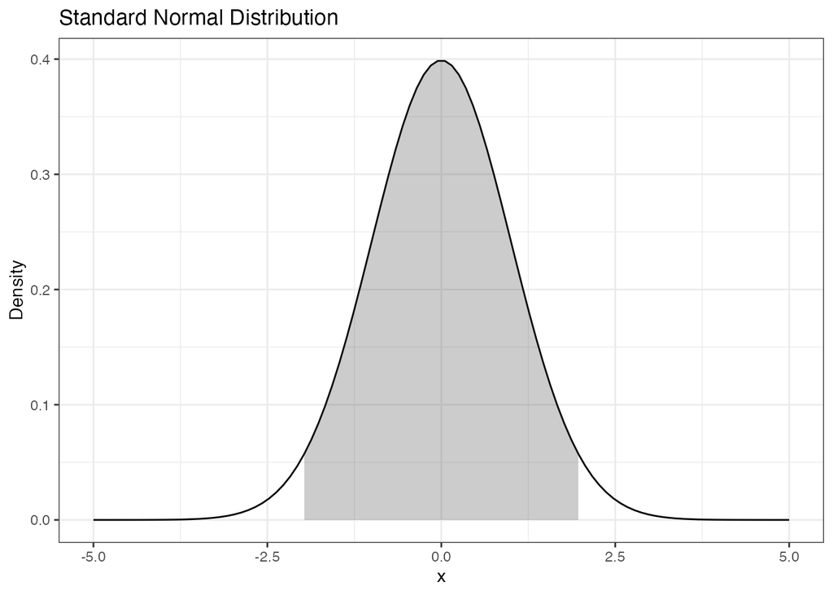

```r
library(tidyverse)

x <- seq(-5, 5, length.out = 100)
y <- dnorm(x, 0, 1)
df_int <- tibble(x, y)

ggplot(df_int, aes(x, y)) +
  geom_line() +
  geom_ribbon(data = df_int %>% filter(x > -2 & x < 2),
              aes(x = x, ymin = 0, ymax = y), alpha = 1/4) +
  labs(x = "x", y = "Density") +
  ggtitle("Standard Normal Distribution") +
  theme_bw()
```

便利な数値積分関数を利用すると、およそ95%とだとわかる(2$\sigma$≒0.95)。

```r
f <- function(x) {dnorm(x = x, mean = 0, sd = 1)}
integrate(f, -2, 2)
```

```
## 0.9544997 with absolute error < 1.8e-11
```

これをモンテカルロシュミレーションで計算する。まずはモデルを定義する。ここでのモデルは標準正規分布なので、モデル式を自分で立式する必要はない。標準正規分布から乱数を発生させて、指定した区間に入る割合を計算すれば、先程と同じ結果が得られる。

```r
set.seed(1989)
n <- 100000
xm <- rnorm(n, mean = 0, sd = 1)
sum(xm >= -2 & xm <= 2)/n
```

```
## [1] 0.95477
```

このようにモデルをもとにランダムな値を利用して計算する方法がモンテカルロシュミレーション。あんまり有り難みがわからないかもしれないので、即解できない問題でモンテカルロシュミレーションの有り難みを感じておく。

下記は対数正規分布で、この分布の0から2までの範囲を積分したい。

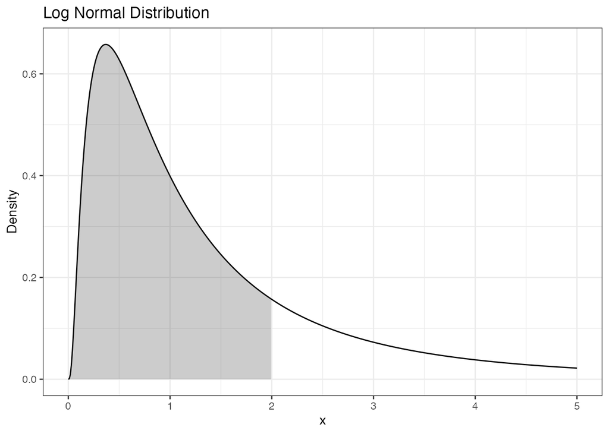

```r
xx <- seq(0, 5, length.out = 500)
yy <- dlnorm(xx, meanlog = 0, sdlog = 1)
df_int2 <- tibble(xx, yy)

ggplot(df_int2, aes(xx, yy)) +
  geom_line() +
  geom_ribbon(data = df_int2 %>% filter(xx > 0 & xx < 2),
              aes(x = xx, ymin = 0, ymax = yy), alpha = 1/4) +
  labs(x = "x", y = "Density") +
  ggtitle("Log Normal Distribution") +
  theme_bw()
```

モンテカルロシュミレーションの結果からおよそ75%ということがわかる。

```r
# f2 <- function(x) {dlnorm(x = x, meanlog = 0, sdlog = 1)}
# integrate(f2, 0, 2)
# 0.7558914 with absolute error < 1.9e-06

set.seed(1989)
xxm <- rlnorm(n, meanlog = 0, sdlog = 1)
sum(xxm >= -2 & xxm <= 2)/n
```

```
## [1] 0.7577
```

## モンテカルロシュミレーションの応用1

ここでは少しモデルを複雑にして、漁業調査などで利用されるリッカーモデルでシュミレーションしてみる。リッカーモデルについては下記を参考にしている。

- [4.6.3 Harvest Policy Analysis](https://bstaton1.github.io/au-r-workshop/ch4.html#harv-ex)
- [8．再生産関係－親子の関係を知る](https://www.fra.affrc.go.jp/kseika/guide_and_manual/afr/pdf/8.pdf)

モデル式は下記の通り。今年戻る新魚は、生まれた年に産卵した産卵魚総数の関数で、リッカーモデルはこの関係をモデル化している。$\alpha$は産卵魚1頭当たりの最大加入数(産卵者数が非常に少ないときに得られる)を表すパラメタで、$\beta$は密度依存性死亡率の強さを表す尺度。誤差項$\varepsilon$は対数正規分布。

$$\begin{equation}
R_{t} = \alpha S_{t-1} e^{-\beta S_{t-1} + \varepsilon_t} ,\varepsilon_t
\sim N(0, \sigma)
\end{equation}$$

モデル式を関数として作成する。本来はパラメタを引数で渡せるようにするべきだが、ここではモデル式にはあまり焦点を当ててないので、関数内部で固定している。ここでは10年分を計算する。

```r
ricker_sim <- function() {
  alpha <- 6
  beta <- 1e-7
  sigma <- 0.05
  U <- 0.2
  n <- 10
  R <- S <- H <- numeric(n)

  # initialize the population in the first year
  R[1] = log(alpha * (1 - U))/(beta * (1 - U)) * exp(rnorm(1, 0, sigma))
  S[1] = R[1] * (1 - U)
  H[1] = R[1] * U

  # Ricker model with lognormal error
  for (t in 2:n) {
    R[t] = S[t-1] * alpha * exp(-beta * S[t-1] + rnorm(1, 0, sigma))
    S[t] = R[t] * (1 - U)
    H[t] = R[t] * U
  }

  return(H)
}
```

モデルが定義できたので、収穫量$H$を計算してみる。結果を見るとわかるが、実行するたびに収穫量が変化している。これはモデル式に含まれる対数正規分布から発生する誤差によるもの。ここでのモンテカルロシュミレーションのランダムな部分は、この誤差の部分になる。

```r
n <- 10
tibble(
  year = 1:n,
  smi1 = ricker_sim(),
  smi2 = ricker_sim(),
  smi3 = ricker_sim()
  )
```

```
## # A tibble: 10 × 4
##     year     smi1     smi2     smi3
##    <int>    <dbl>    <dbl>    <dbl>
##  1     1 3526834. 3680331. 3768113.
##  2     2 4152218. 4449600. 3985825.
##  3     3 3583695. 3412298. 3877291.
##  4     4 4165032. 4020356. 4011557.
##  5     5 3517921. 4087042. 3994921.
##  6     6 3917072. 3674620. 3929992.
##  7     7 3680390. 4033497. 3946107.
##  8     8 4416956. 4081303. 3887846.
##  9     9 3576575. 3732293. 3967593.
## 10    10 4534739. 4133912. 4010246.
```

10年間の収穫量の変化を500回ほどシュミレーションする。シュミレーション結果は10行×501列のデータフレームで返される。

```r
# replicate(n = n, expr = ricker_sim())と同じようなこと
set.seed(1989)
sim_n <- 500

df_sim_ricker <- map_dfc(.x = 1:sim_n, .f = function(x){ricker_sim()}) %>%
  set_names(paste0('sim', 1:sim_n)) %>%
  bind_cols(tibble(year = 1:n))

head(df_sim_ricker)
```

```
## # A tibble: 6 × 501
##       sim1   sim2   sim3   sim4   sim5   sim6   sim7   sim8   sim9  sim10  sim11
##      <dbl>  <dbl>  <dbl>  <dbl>  <dbl>  <dbl>  <dbl>  <dbl>  <dbl>  <dbl>  <dbl>
## 1 4143800. 4.20e6 3.83e6 3.67e6 4.17e6 3.94e6 3.84e6 3.74e6 3.90e6 4.05e6 4.28e6
## 2 4009249. 4.01e6 4.35e6 4.07e6 3.80e6 3.80e6 4.06e6 4.00e6 4.12e6 4.03e6 3.64e6
## 3 3534653. 3.82e6 3.40e6 3.72e6 4.19e6 3.87e6 3.85e6 3.98e6 3.67e6 4.01e6 3.92e6
## 4 4086338. 4.39e6 3.74e6 4.18e6 3.65e6 4.11e6 3.76e6 3.78e6 3.49e6 3.83e6 4.14e6
## 5 3710142. 3.22e6 4.18e6 3.67e6 4.26e6 4.10e6 3.99e6 4.32e6 4.34e6 3.95e6 3.67e6
## 6 3968213. 4.37e6 3.96e6 4.17e6 3.92e6 3.73e6 3.94e6 3.56e6 3.87e6 4.11e6 4.07e6
## # ℹ 490 more variables: sim12 <dbl>, sim13 <dbl>, sim14 <dbl>, sim15 <dbl>,
## #   sim16 <dbl>, sim17 <dbl>, sim18 <dbl>, sim19 <dbl>, sim20 <dbl>,
## #   sim21 <dbl>, sim22 <dbl>, sim23 <dbl>, sim24 <dbl>, sim25 <dbl>,
## #   sim26 <dbl>, sim27 <dbl>, sim28 <dbl>, sim29 <dbl>, sim30 <dbl>,
## #   sim31 <dbl>, sim32 <dbl>, sim33 <dbl>, sim34 <dbl>, sim35 <dbl>,
## #   sim36 <dbl>, sim37 <dbl>, sim38 <dbl>, sim39 <dbl>, sim40 <dbl>,
## #   sim41 <dbl>, sim42 <dbl>, sim43 <dbl>, sim44 <dbl>, sim45 <dbl>, …
```

このシュミレーション結果を利用して、平均やパーセンタイルを計算して、大まかな変化を可視化できるようする。

```r
# apply(df_sim_ricker, 1, mean)と同じ
df_sim_ricker_mean <- df_sim_ricker %>%
  rowwise() %>%
  mutate(
    mean = mean(c_across(-year)),
    q10 = quantile(c_across(-year), probs = 0.1),
    q90 = quantile(c_across(-year), probs = 0.9)
  ) %>%
  select(year, mean, q10, q90)
df_sim_ricker_mean
```

```
## # A tibble: 10 × 4
## # Rowwise:
##     year     mean      q10      q90
##    <int>    <dbl>    <dbl>    <dbl>
##  1     1 3938718. 3690458. 4192235.
##  2     2 3920779. 3639299. 4202172.
##  3     3 3913156. 3617632. 4204878.
##  4     4 3936278. 3622331. 4268106.
##  5     5 3909265. 3585700. 4220808.
##  6     6 3931391. 3625254. 4243984.
##  7     7 3910236. 3626344. 4221030.
##  8     8 3926921. 3657885. 4219846.
##  9     9 3909132. 3602601. 4202726.
## 10    10 3915872. 3641086. 4215818.
```

シュミレーション結果も合わせて可視化したいので、テーブルの構造をロング形式にしておく。

```r
df_sim_ricker_long <- df_sim_ricker %>%
  pivot_longer(
    cols = -year,
    names_to = 'sim',
    values_to = 'harvest'
  ) %>%
  arrange(sim, year)
df_sim_ricker_long
```

```
## # A tibble: 5,000 × 3
##     year sim    harvest
##    <int> <chr>    <dbl>
##  1     1 sim1  4143800.
##  2     2 sim1  4009249.
##  3     3 sim1  3534653.
##  4     4 sim1  4086338.
##  5     5 sim1  3710142.
##  6     6 sim1  3968213.
##  7     7 sim1  3949324.
##  8     8 sim1  4011470.
##  9     9 sim1  3897416.
## 10    10 sim1  3800951.
## # ℹ 4,990 more rows
```

モンテカルロシュミレーションを可視化すると、このような形で収穫量の推移を確認できる。

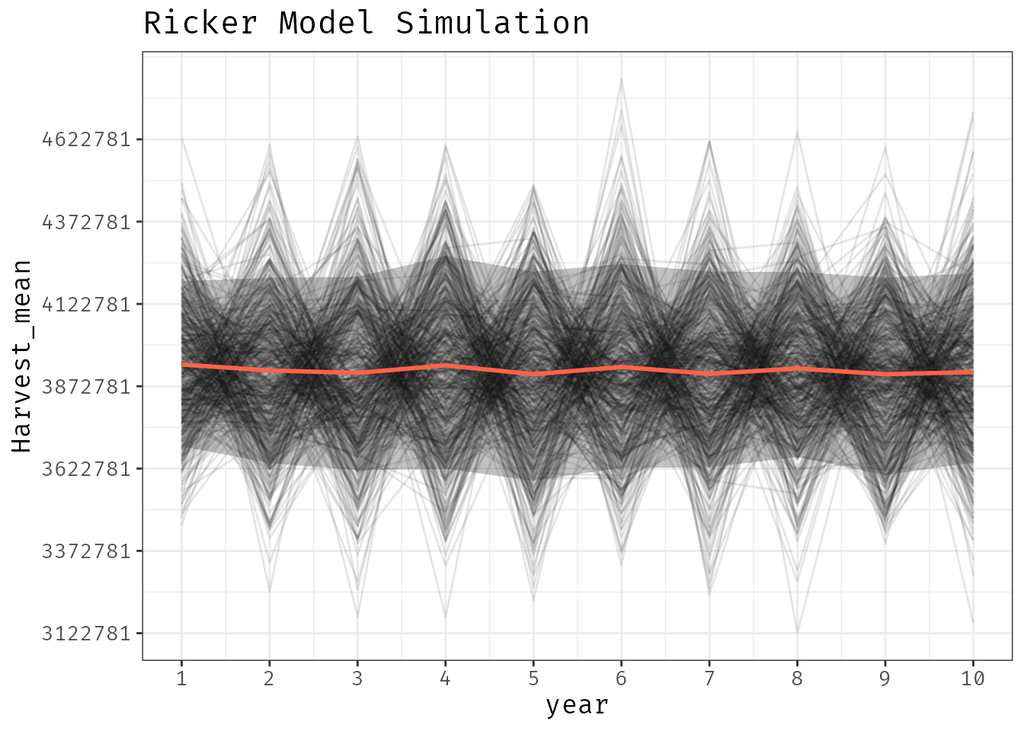

```r
ggplot() +
  geom_line(data = df_sim_ricker_long, aes(x = year, y = harvest, group = sim), alpha = 0.1) +
  geom_ribbon(data = df_sim_ricker_mean, aes(x = year, ymin = q10, ymax = q90), alpha = 0.3) +
  geom_line(data = df_sim_ricker_mean, aes(x = year, y = mean), col = 'tomato', size = 1) +
  scale_x_continuous(breaks = seq(1:n)) +
  scale_y_continuous(
    breaks = seq(
      min(df_sim_ricker_long$harvest),
      max(df_sim_ricker_long$harvest),
      250000)) +
  labs(title = "Ricker Model Simulation", y = 'Harvest_mean') +
  theme_bw() +
  theme(legend.position = 'none', text = element_text(family = "Fira code", size = 13))
```

このようにモンテカルロシュミレーションを使用ことで、関心のあるモデルから生成された値をランダム性を利用してシュミレーションできる。今回は、誤差項の部分を乱数を利用しているが、他のパラメタを同時に変化するほうが現実的なので、様々なパラメタが様々な値に変換する現実に即したモデルをシュミレーションすることで、実用的に活用できる。

## モンテカルロシュミレーションの応用2

次は別の問題をシュミレーションしてみる。1から500までが記入されたカードがあり、全てのカードを集めるのに、いくら費用がかかるだろうか。カードは等確率で出るものであり、1枚あたり10円の費用がかかる。購入枚数を確定して、カードを手にした際に、足りていない番号のカードは、1枚50円で買い足すことで全ての番号のカードを揃えるとする。

シュミレーション用の関数はこちら。

```r
cards_sim <- function(n){
  price <- c(10, 50)

  cards <- sample(1:500, size = n, replace = TRUE)
  n_get_cards <- length(unique(cards))
  n_not_get_cards <- 500 - n_get_cards
  total_price <- n*price[1] + n_not_get_cards*price[2]
  return(total_price)
}
```

500枚しか購入せず、すべて揃わなかった場合は買い足すことにし、10000回のシュミレーションを起こった結果が下記である。14000円前後が平均の正規分布のようになった。

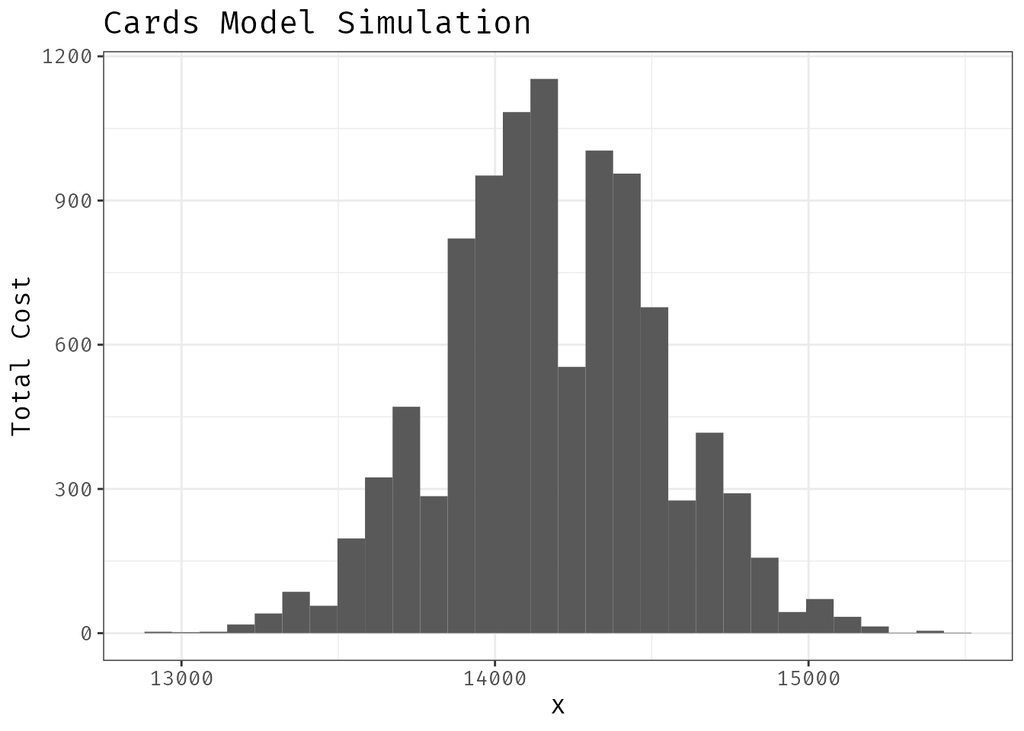

```r
set.seed(1989)
ggplot(tibble(x = replicate(10000, cards_sim(n=500))), aes(x)) +
  geom_histogram() +
  labs(title = "Cards Model Simulation", y = 'Total Cost') +
  theme_bw() +
  theme(text = element_text(family = "Fira code", size = 13))
```

枚数ごとの平均金額を返す関数を作成し、その関数を使って「何枚くらい購入するのが良いか」をシュミレーションしてみる。シュミレーション結果を見る限り、800枚くらいを購入すれば、平均13000円くらいで全てのカードを揃えることができることがわかる。これ以上だと、不要なカードが多すぎて出費がかさんでいる様子が確認できる。

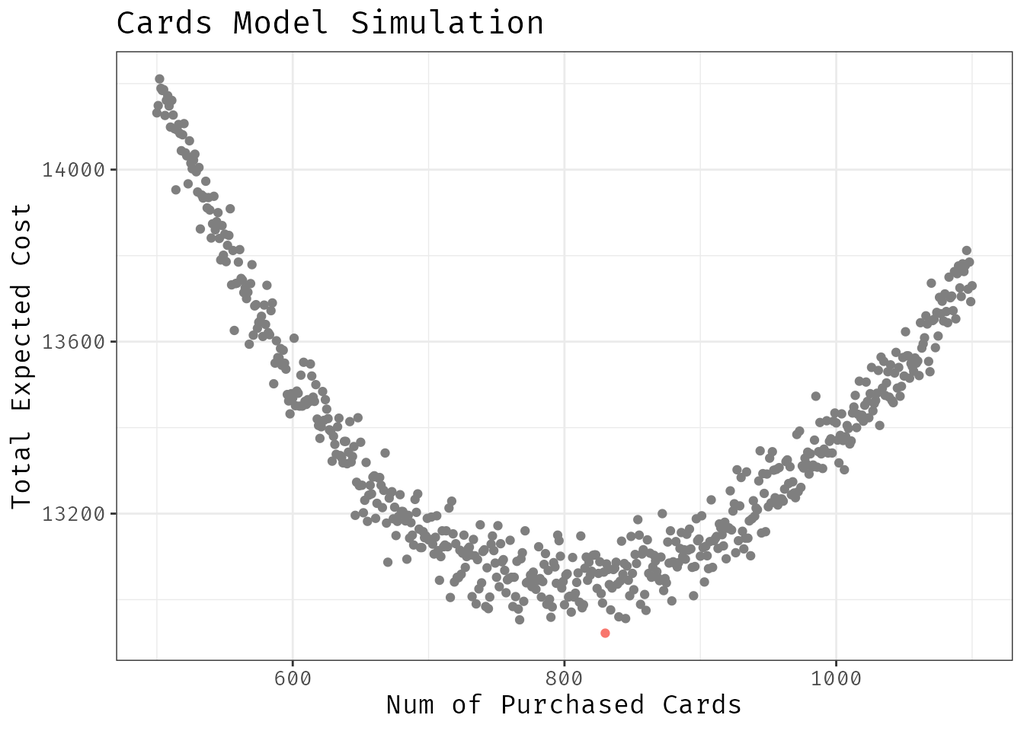

```r
expected_price <- function(n){
  mean(
    # map_dbl(.x = 1:100, .f = function(x){cards_sim(n)})
    map_dbl(1:50, ~ cards_sim(n))
  )
}

p <- map_dbl(.x = 500:1100, .f = function(x){expected_price(x)})
tibble(j = 500:1100, p) %>%
  mutate(min_price = if_else(min(p) == p, j, NA)) %>%
  ggplot(., aes(j, p, col = as.character(min_price))) +
  geom_point() +
  labs(title = "Cards Model Simulation",
       y = 'Total Expected Cost',
       x = 'Num of Purchased Cards') +
  theme_bw() +
  theme(legend.position = 'none', text = element_text(family = "Fira code", size = 13))
```

## 財務モデリング

モンテカルロシュミレーションは財務モデリングでも利用できる財務モデルを作成し、各パラメタをランダムに変化させることで、収益を予想できる。ただ、財務モデルが現実に即していなければ数字あそびにしかならない。

```r
# library(truncnorm)
# rtruncnorm(100, a = 0.4, b = 0.6, mean = 0.5, sd = 0.1)
#
# n <- 10000
# epsilon <- 0.001
# y <- numeric(n)
# a <- numeric(n)
# b <- numeric(n)
# c <- numeric(n)
# d <- numeric(n)
# generate_abc <- function() {
#   trials <- 0
#   valid <- FALSE
#
#   while(!valid) {
#
#     a <- runif(1, 0.40, 0.50)
#     b <- runif(1, 0.30, 0.40)
#     c <- runif(1, 0.05, 0.30)
#     d <- runif(1, 0.05, max(0.10, 1 - a - b - c))
#     if(abs(1 - (a + b + c + d)) < epsilon) valid <- TRUE
#   }
#   return(c(a, b, c, d))
# }
#
# mat <- matrix(0, nrow = 4, ncol = n)  # 空の行列を作成
# pb <- progress::progress_bar$new(
#   format = "[:bar] :percent :elapsed",
#   total = n
# )
#
# for(i in 1:n) {
#   mat[, i] <- generate_abc()
#   y[i] <-
#     100  * mat[1, i] +
#     50   * mat[2, i] +
#     1000 * mat[3, i] +
#     1000 * mat[4, i]
#   pb$tick()  # 進捗を更新
# }
#
# progress::pb$terminate()
#
# hist(y)
# summary(y)
# summary(a)
# summary(b)
# summary(c)
# summary(d)
#
# # ---------------------------------
#
# # 初期ユーザー数
# init_num <- 1000
#
#
# sim <- function(init_num) {
#   repeat_num <- sample(2:4, 1)
#   repeat_rates <- seq(0.2+rnorm(1,0.1,0.05), 0.8+rnorm(1,0.1,0.05), length.out = repeat_num)
#   result <- numeric(repeat_num)
#
#   result[1] <- init_num
#   for(i in 1:(length(repeat_rates)-1)) {
#     result[i+1] <- floor(result[i] * repeat_rates[i])
#   }
#   return(result)
# }
#
#
# run_simulations <- function(init_num, num_simulations) {
#   simulation_results <- list()
#
#   for (i in 1:num_simulations) {
#     result <- sim(init_num)
#     simulation_results[[i]] <- result
#   }
#
#   return(simulation_results)
# }
#
# num_simulations <- 10
#
# results <- run_simulations(init_num, num_simulations)
# results
```